# Tres problemas para el análisis cuantitativo de los femicidios en Ecuador

Alejandra Marchán y Daniel Sánchez

2023-01-07

# El Problema Estadístico y Organizacional

En Ecuador se registran las muertes violentas de mujeres desde agosto 2014, año en el que se tipificó el delito de femicidio en el COIP[^1] hasta finales de 2022, momento en el que los autores recuperaron los datos del [reporte](https://www.fiscalia.gob.ec/analitica-muertes-de-mujeres-en-contexto-delictivo/) oficial presentado periódicamente por el Gobierno Nacional, mediante la Comisión Especial de Estadística de Seguridad, Justicia, Crimen y Transparencia[^2]. Las cifras separan a las muertes de mujeres en dos categorías diferentes. Una es el femicidio: “una persona que, como resultado de relaciones de poder manifestadas en cualquier tipo de violencia, da muerte a una mujer por el hecho de serlo o por su condición de género”[^3].

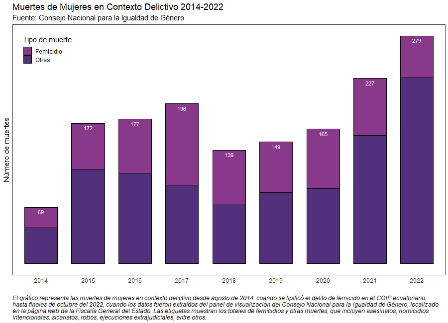

La minoría de muertes violentas de mujeres durante el período se clasifican como femicidios, quizás debido a la dificultad de identificación que este delito tiene. El COIP sitúa al femicidio como un crimen de odio contra la mujer *por el hecho de serlo*, sin embargo, al ser dificultoso conocer los motivos del criminal, los agentes de la ley se han centrado en aspectos conductuales para poder sentenciar a los femicidas<sup>[1]</sup>. La segunda categoría del reporte oficial contiene muertes violentas que no se sentenciaron como femicidio, incluyendo aquellas muertes de mujeres por “homicidios intencionales”[^4]. Bajo esta aclaración, sería posible pensar que dada la dificultad de sentenciar un femicidio, buena parte de los *femicidios reales* podría estar dentro de esta cifra, pero no se conoce en que proporción.

El reporte oficial no brinda acceso a los datos ni a un documento metodológico. Lo que se logró conocer es que el aumento en muertes se debió a muertes que *no* son femicidios, pero se requiere más información para saber esto. Se redirecciona al [sitio web de estadística](https://www.fiscalia.gob.ec/estadisticas-fge/) de la Fiscalía General del Estado (FGE) en el reporte oficial[^5], de donde se determinó lo siguiente:

- La base proporcionada por la FGE está nivel de denuncias, por lo que no existe una manera de replicar los cálculos de femicidios que la FGE y el reporte oficial presenta.
- Se menciona que *en algunos casos las víctimas no son identificadas o son desconocidas y por tanto la variable tiene subregistro.*[^6], por lo que aparentemente incluso la FGE desconoce como se generan cifras de femicidios.
- La base no es suficiente para replicar el reporte oficial debido a que los datos están esparcidos en diferentes instituciones públicas[^7] y no todas proporcionan información al público.

A continuación, se grafican los datos de denuncias proporcionados por la FGE.

[figure not shown]

Como se esperaría con un delito tipificado recientemente, el número de denuncias aumentó de forma inmediata después de tipificarse en el COIP. En 2015 tuvo el pico de denuncias, lo que no coincide con el número de víctimas de femicidio reportadas por el Gobierno. Se tiene una tasa de crecimiento considerable después de la introducción del delito, lo que probablemente corresponde a denuncias de femicidios que *no* sucedieron durante ese mismo año. Esto genera dos problemas diferentes para nuestros propósitos:

1. El número de denuncias dentro de un año puede ser de crímenes cometidos en años anteriores.
2. Existe un gran número de crímenes que jamás se llegan a denunciar.

Este problema es complicado de resolver, y no conocemos como la FGE lo resolvió para la generación de las cifras del reporte oficial, sin nisiquiera conocer o revelar la relación denuncia-víctima.

Dos otras instituciones públicas ofrecen información. Una es el Ministerio de Gobierno, donde se determinó que sus [cifras de femicidios](http://cifras.ministeriodegobierno.gob.ec/comisioncifras/inicio.php) coinciden con las del reporte oficial. Sin embargo, esta institución dejó de diferenciar delitos por género desde 2014. Otra fuente fueron las defunciones generales del Registro Civil, disponibles en el [INEC](https://www.ecuadorencifras.gob.ec/defunciones-generales/#:~:text=En%20el%20a%C3%B1o%202021%20se,de%20la%20publicaci%C3%B3n%20es%20anual.). Se pudo obtener el número de muertes violentas, en donde sí es posible realizar una diferenciación a nivel de género. Sin embargo, no existe una categorización de muertes por delito.

[figure not shown]

Es posible realizar una comparación de muertes violentas entre hombres y mujeres, en donde la cifra de muertes violentas de mujeres es comparable al total que se puede ver en el primer gráfico. En el gráfico anterior se observa el porcentaje de muertes violentas de mujeres como porcentaje del total (hombres + mujeres). Las muertes violentas de mujeres según el INEC llegaron a su pico durante el 2017 y desde ese año han caíd considerablemente; de hecho se encuentran en su punto más bajo en 2022. Sin embargo, al no tener una desagregación por delito, los datos no se puden comparar con la cifra de femicidios presentada.

# El Problema de los Datos de la Sociedad Civil

Con el objetivo de tener información de una fuente no gubernamental, tomamos en cuenta la información de la Alianza Feminista para el mapeo de *femi(ni)cidios*[^8] en Ecuador. Las [cifras](http://www.fundacionaldea.org/mapas) de feminicidios de la Alianza han sido reportadas principalmente por la Fundación Asociación Latinoamericana para el Desarrollo Alternativo (ALDEA), mediante un [reporte interactivo](http://80.241.217.8/mapas_estadisticos/femi_pro/#).

Zambrano et al.<sup>[4]</sup> realizan una revisión sistemática de esta información, en donde se menciona que los datos de ALDEA son consecuentes con el [Modelo de protocolo latinoamericano de investigación de la muerte violenta de mujeres por razones de género, femicidio/feminicidio](https://www.unwomen.org/es/digital-library/publications/2014/8/modelo-de-protocolo-latinoamericano#:~:text=El%20Modelo%20de%20Protocolo%20latinoamericano,la%20violencia%20contra%20las%20mujeres.)[^9]. Particularmente, se señala que se consideran asesinatos de mujeres en contexto de narcotráfico. Esto representa un problema para comparar esta fuente con los femicidios reportados por el gobierno, puesto que los casos contra femicidas suelen construirse en casos de relaciones sentimentales tornadas violentas, y no en casos de delincuencia organizada. Esto hace que necesariamente el indicador de ALDEA sea *siempre* superior al indicador del reporte oficial del gobierno. En el gráfico siguiente comparamos los datos de ALDEA con las muertes violentas (totales) del reporte oficial (abreviado como FGE) y con los datos del Registro Civil.

[figure not shown]

Existe un problema adicional con este indicador: en 2021 se incluyeron los asesinatos de mujeres por sicariato<sup>[4]</sup>, lo que no coincide con el femicidio según la legislación ecuatoriana. El aumento de 2020 a 2021 es entonces artificial puesto a que antes ALDEA no había tomaba sicariatos en cuenta. Por ende, no se puede esperar que este indicador sea comparable al femicidio oficial, sino más bien al total de muertes violentas. En este caso, el indicador de ALDEA está subestimado.

Nos contactamos con la fundación ALDEA para solicitar acceso a sus datos, pero nuestra solicitud no fue aprobada por la organización[^10]. Esto dificulta la tarea de analizar el aumento de femicidios que ALDEA reporta para 2022. Sin embargo, debido a la inclusión de los sicariatos y muertes en contexto de delincuencia organizada en este indicador, se podría argumentar que los femicidios han aumentado debido al incremento generalizado de la violencia en el Ecuador de los últimos dos años.

# El Problema de Rendición de Cuentas

Una reducida publicación de datos y problemas en el mantenimiento de bases de datos abiertas evidencian un problema grave: el problema de rendición de cuentas, en donde las instituciones estatales muestran poco o ningún incentivo de demostrar al público lo que se investiga y sobre lo que se pretende hacer justicia. La sociedad civil lleva algunos pasos por delante, pero debemos caminar hacia el acceso abierto de datos si se pretende realmente llegar a un ambiente de libre intercambio de información para formular una mejor política pública.

Las debilidades cuantitativas del Estado ecuatoriano no son más que una consecuencia de la gigantesca dificultad que existe en navegar el coloso estatal que existido desde tiempos inmemorables, por lo que no se puede culpar a un gobierno u otro de su existencia[^11], sino más bien empezar a preguntarse cómo solucionar el problema. Algunas de las maneras en las que podríamos mejorar el intercambio de datos son:

- Fomentar la elaboración de documentos metodológicos extensos y claros para poder justificar la validez de lo presentado. Esto asegura transparencia y ahorra tiempo al usuario, quien probablemente no tiene la misma experiencia de quienes elaboran los reportes.
- Implementar buenas prácticas en el mantenimiento de bases de datos. Un problema que se volvió evidente durante nuestro análisis fue la extensa limpieza que se requirió para utilizar los datos del Registro Civil presentados por el INEC. Principios básicos como mantener constante el nombre de una misma variable a lo largo de los años, deberían cumplirse siempre en una institución como el INEC.
- En los casos donde la privacidad y la factibilidad económica lo permitan, fomentar el uso de bases de datos abiertas al público. Sirve de muy poco tener visualizaciones atractivas si no se pueden obtener las bases de datos para poder continuar el análisis.
- Una integración institucional adecuada del sector público que sea visible y útil para los usuarios. La necesidad de navegar a través de diferentes ministerios, secretarias y consejos para conseguir una simple explicación es tediosa e infactible al largo plazo. El [Banco de Datos Abiertos](https://www.datosabiertos.gob.ec/) es un intento de esta integración, pero aun requiere mucho trabajo.

Implementar estas prácticas en el sector publico y sociedad civil significarían un importante paso hacia un sistema fiable y abierto de datos. Sin un sistema así no existirán mecanismos de rendición de cuentas en donde las instituciones públicas involucradas justifiquen su razón de existir y donde los tomadores de decisiones puedan crear política pública efectiva basada en información científica.

1. Físcalía General del Estado. (n.d.). *Fiscalía General del Estado | “Tipificar el femicidio es un gran paso de la legislación ecuatoriana”, fiscal Tania Moreno*. https://www.fiscalia.gob.ec/tipificar-el-femicidio-es-un-gran-paso-de-la-legislacion-ecuatoriana-fiscal-tania-moreno/

2. Consejo Nacional de Igualdad de Género. (2022). *Analítica muertes de mujeres en contexto delictivo*. https://www.fiscalia.gob.ec/analitica-muertes-de-mujeres-en-contexto-delictivo/

3. Panamá, G.-L. E. de. (n.d.). *Femicidio o feminicidio, ¿cuál es el término correcto?* https://www.laestrella.com.pa/nacional/191124/femicidio-feminicidio-termino-correcto

4. Zambrano, G. C., & Guerra Garcés, G. (2022). *Femicidios en Ecuador: Realidades ocultas, datos olvidados e invisibilizados* (p. 78). https://nube.fundacionaldea.org/index.php/s/QqmLd25Ex596g36

5. Adoum, J. E. (2000). *Ecuador: Señas particulares* (6th ed., Vol. 1). Eskeletra Editorial.

[^1]: Código Orgánico Integral Penal, el cuerpo de ley que regula el poder punitivo del estado ecuatoriano [@códigoo].
[^2]: Esta comisión constituye a varias diferentes instituciones gubernamentales, pero el reporte en cuestión está colgado en la página web de la Fiscalía General del Estado. En adelante, nos referimos a este esfuerzo como simplemente <<reporte oficial>>.
[^3]: COIP, art. 141. Recuperado de la base metodológica del reporte oficial<sup>[1]</sup> (párr. 5).
[^4]: Según el reporte del Gobierno, se considera un homicidio intencional a “la muerte ilícita causada a una persona con la intención de causarle la muerte o lesiones graves”<sup>[2]</sup>
[^5]: El sitio web de la FGE no proporciona acceso a los datos. Los autores realizamos un pedido de información al correo electrónico proporcionado por la FGE, estadistica@fiscalia.gob.com, para los delitos de Femicidio (Art. 141), Homicidio (Art. 144), Asesinato (Art. 140), Sicariato (Art. 143) y Violación (Art. 171).
[^6]: Esta es la nota que se incluye en la base de datos original de la FGE, disponible en el repositorio de GitHub de este artículo.
[^7]: Los analistas de la FGE mencionaron que *se debe observar que la Fiscalía dispone de información de gestión procesal de la justicia. El tema de sentencias corresponde a la Judicatura. Es más, para determinar propiamente al sujeto como víctima o victimario se debe considerar las sentencias.* Esto lleva a entender que la información que la FGE está dispuesta a proporcionar no es suficiente para generar las visualizaciones que ellos presentan (y de acuerdo a sus documentos, que también elaboran). El Consejo de la Judicatura no consta con un correo electrónico para realizar pedidos de información.
[^8]: En general, el término feminicidio es diferente al femicidio debido a que el primero abarca un sentido político en contra del gobierno por la falta de acción ante el asesinato de una mujer *por el hecho de ser mujer*, es decir, el feminicidio acarrea el concepto de la impunidad que un Estado desatento genera<sup>[3]</sup>.
[^9]: Este documento, publicado en 2014, dió paso a la investigación penal del delito de femicidio, lo que habría permitido al estado ecuatoriano tipificar el mismo en agosto del mismo año.
[^10]: Un responsable de la organización citó que los datos no se suelen revelar **nunca** a externos debido a preocupaciones de seguridad.
[^11]: Véase Adoum<sup>[5]</sup>.